# Diversificação nos investimentos é o último almoço grátis

Wilson Freitas

O R oference um ambiente muito rico para análise e processamento de dados financeiros. Há diversos pacotes para acesso a dados do mercado financeiro e sem custos. Pacotes como quantmod, rbcb e GetTDData são exemplos de pacotes disponíveis para instalação, sem custo e que dão acesso a uma extensa base de dados econômicos e financeiros totalmente integrados ao ambiente do R.

Neste post vamos utilizar o pacote quantmod para obter algumas séries temporais de preços de ativos financeiros e fazer uma avaliação do desempenho destes ativos. A biblioteca PerformanceAnalytics possui diversas funções para avaliação de desempenho de ativos, muito útil na comparação de fundos de investimentos e avaliação do desempenho dos fundos contra seus *benchmarks*. Esta biblioteca traz diversos gráficos e tabelas que enriquecem essa análise e alguns deles serão apresentados ao longo deste texto. O objetivo aqui é selecionar alguns ativos mais conhecidos do grande público e avaliar o desempenho de cada um destes ativos utilizando as funções da biblioteca PerformanceAnalytics.

Começemos carregando os pacotes que serão utilizados.

```r
library(tidyverse)
library(PerformanceAnalytics)
library(xts)
library(quantmod)
```

Vamos carregar os dados dos seguintes ativos:

- Petrobrás PN (PETR4.SA)
- VALE (VALE3.SA)
- Lojas Renner (LREN3.SA)
- Ambev (ABEV3.SA)
- ETF BOVA11 (BOVA11.SA)

Para isso vamos usar uma artifício utilizado no [blog do RStudio](https://rviews.rstudio.com/2017/11/09/introduction-to-visualizing-asset-returns/) onde um vetor com os símbolos dos ativos é definido e em seguida, com um conjuto de operações com *pipes* as séries são colocadas juntas em um único objeto `xts`.

```r
symbols <- c("BOVA11.SA", "ABEV3.SA", "LREN3.SA", "PETR4.SA", "VALE3.SA")

prices <- getSymbols(symbols,
                     from = "2010-01-01",
                     to = "2020-01-01",
                     auto.assign = TRUE) %>%
  map(~Ad(get(.))) %>%
  reduce(merge) %>%
  `colnames<-`(symbols)
```

Este é um código *tricky* que merece ser estudado com calma, sugiro fortemente a leitura do [blog do RStudio](https://rviews.rstudio.com/2017/11/09/introduction-to-visualizing-asset-returns/). Por ora vamos nos ater a seu resultado, o objeto `prices`.

```r
head(prices)
```

```
##            BOVA11.SA ABEV3.SA LREN3.SA PETR4.SA VALE3.SA
## 2010-01-04     69.37 2.582460 2.519617 31.19617 33.24646
## 2010-01-05     69.90 2.597651 2.428848 30.92868 33.55638
## 2010-01-06     70.30 2.624151 2.381902 31.34663 34.26664
## 2010-01-07     70.00 2.636473 2.359987 31.05406 34.40870
## 2010-01-08     69.48 2.631408 2.372509 30.88688 34.74445
## 2010-01-11     69.99 2.599336 2.416331 30.78657 34.64114
```

Neste objeto temos todos os preços diário dos ativos entre os anos de 2010 e 2019, ou seja, uns 10 anos de dados. O objeto `prices` possui séries de preços, entretanto, as análises de desempenho devem ser feitas com as séries de **retornos** dos ativos. Aqui vamos utilizar a função `Return.calculate` do pacote PerformanceAnalytics para calcular os log-retornos.

```r
returns <- Return.calculate(prices, method = "log")
```

Calculados os retornos, vamos observá-los com a função `chart.TimeSeries`, também do PerformanceAnalytics. É muito importante vizualizar os dados e *ver* como eles se comportam. Isso faz parte da análise, ajuda na compreensão e principalmente no processo de formulação de perguntas. Lembre-se, *as perguntas no processo de análise dados são mais importantes do que as respostas*.

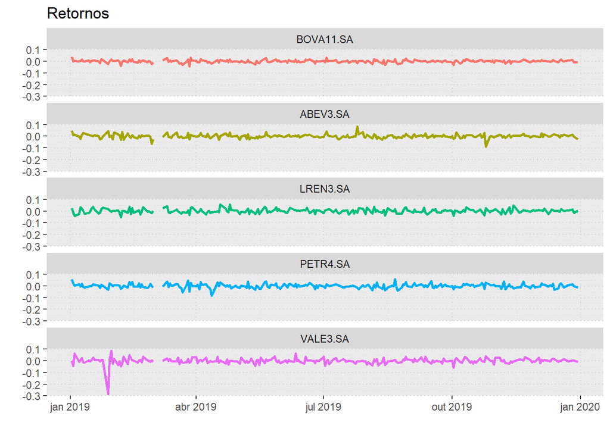

```r
returns["2019"] %>%
  chart.TimeSeries(plot.engine = "ggplot2", main = "Retornos") +
  facet_wrap(. ~ security, ncol(returns)) +
  theme(legend.position = "none")
```

Note que nessa função usamos o `plot.engine = "ggplot2"` que cria um objeto do ggplot2. A partir desse gráfico podemos fazer as customizações usando a sintaxe do ggplot2. Aqui aplicamos o `facet_wrap` para separar os gráficos em linhas e removemos a legenda, uma vez que o nome de cada ativo vem no topo de gráfico. Neste gráfico colocamos os retornos apenas de 2019. É interessante observar que os eixos y de todos os gráficos têm a mesma escala e que ela vai de +0,1 (aproximadamente 10%) até -0,3 (aproximadamente -30%). Podemos observar que a VALE teve uma queda grande no começo de 2019, no primeiro mês do ano. Isso é consequência do acidente em Brumadinho, o [rompimento da barreira](https://g1.globo.com/mg/minas-gerais/noticia/2019/01/25/bombeiros-e-defesa-civil-sao-mobilizados-para-chamada-de-rompimento-de-barragem-em-brumadinho-na-grande-bh.ghtml).

A primeira análise é o cálculo dos retornos acumulados, dado que os retornos são a variação percentual diária do ativo, os retornos acumulados apresentam o *ganho* (ou perda) do ativo no período. Para simplificar vamos considerar o investimento de R$ 1,00 no começo do período e vamos avaliar a evolução deste investimento nestes 10 anos, se no fim tivermos mais de R$ 1,00 o investimento teve um retorno positivo no período, caso contrário teve perda pois chegou-se ao fim com menos do que tinha no começo do ano. A função `chart.CumReturns` apresenta as séries de retornos acumulados para todos os ativos.

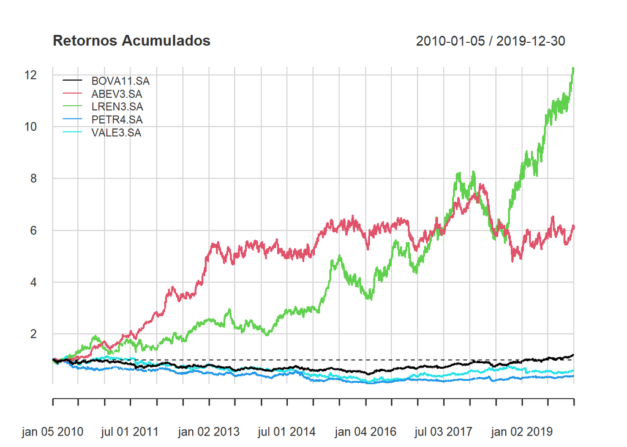

```r
{
  chart.CumReturns(returns, wealth.index = TRUE, main = "Retornos Acumulados", legend.loc = 'topleft')
  lines(xts(rep(1, nrow(returns)), time(returns)), col = "black", lty = 2)
}
```

Aqui usamos também a função `lines` para traçar uma linha pontilhada marcando R$ 1,00 e por este motivo usamos as chaves `{}` para criar um bloco único onde o resultado é o gráfico. Isso é útil para fazer composição de gráficos quando utilizamos o Rmarkdown.

Observando o gráfico, vemos que o 1,00 Real investido em Lojas Renner foi multiplicado por 12, o investimento em Ambev foi multiplicado por 6, enquanto Petrobrás e Vale chegam ao fim do período com menos do que foi colocado inicialmente. Considerando o índice IBOVESPA no período, ele chega no fim quase no zero à zero. Conhecendo o índice IBOVESPA, temos que Petrobrás e Vale possuem um grande peso no índice, entretanto o resultado no índice foi melhor do que os resultados individuais das empresas. Logo, a conclusão natural é que as demais empresas no índice, mesmo com um peso menor na sua composição, conseguiram melhorar o resultado no fim do período.

Observando o histórico realizado, é fácil concluir que o investimento em Lojas Renner e Ambev foi muito melhor do que o investimento em Vale e Petrobrás, entretanto, estas últimas empresas foram grandes responsáveis pelo crescimento do índice nos anos anteriores.

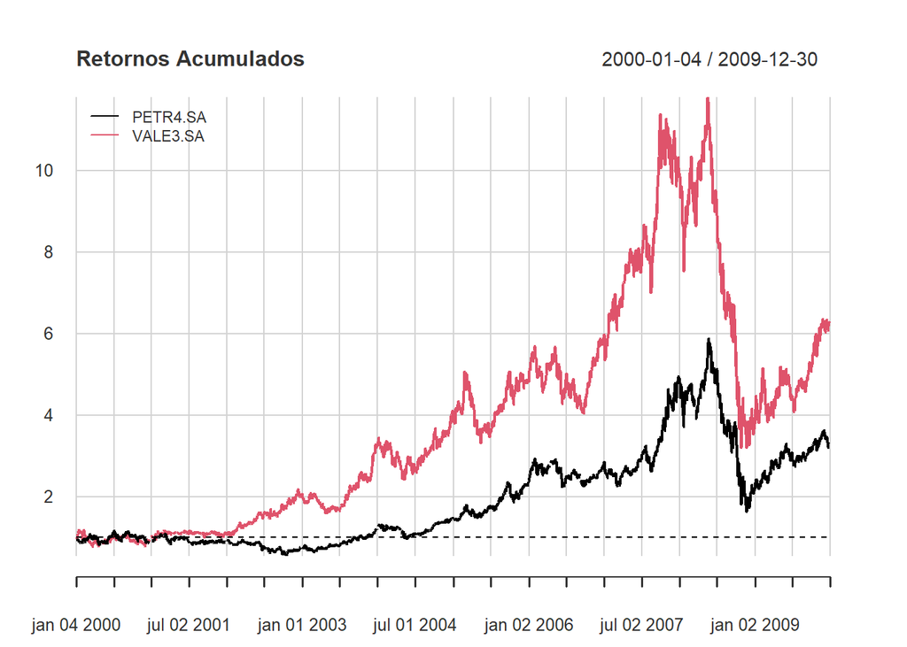

```r
symbols <- c("PETR4.SA", "VALE3.SA")

prices_before <- getSymbols(symbols,
                     from = "2000-01-01",
                     to = "2010-01-01",
                     auto.assign = TRUE) %>%
  map(~Ad(get(.))) %>%
  reduce(merge) %>%
  `colnames<-`(symbols)

returns_before <- Return.calculate(prices_before, method = "log")

{
  chart.CumReturns(returns_before, wealth.index = TRUE, main = "Retornos Acumulados", legend.loc = 'topleft')
  lines(xts(rep(1, nrow(returns_before)), time(returns_before)), col = "black", lty = 2)
}
```

O gráfico acima traz as ações Petrobrás e Vale na década anterior, nota-se que até a crise de 2008 (Crise dos Subprime), a Vale entregava um retorno multiplicado por 10 e a Petrobrás com múltiplo de 6. Mesmo após a crise ambas apresentaram forte recuperação. Logo, para a década seguinte é razoável considerar e estas ações faziam parte de grande parte das carteiras de investimento.

O ponto que eu quero colocar aqui é, **não há bola de cristal para investimentos**. Tem aqui duas ações que foram um sucesso na primeira década do século e foram um total fracasso na década seguinte. Isso com certeza aconteceu com diversas outras ações. Para o investidor pessoa física, é muito difícil, talvez praticamente impossível, acertar o *timing* de entrada e saída dos investimentos em ações. Essa tarefa já é desafiadora para investidores profissionais, que possuem grandes equipes dedicadas ao acompanhamento das empresas e dos mercado, imaginem para investidores pessoa-física apenas com computadores pessoais e acesso ao Google, sem chance!

Vamos voltar para a década de 2010-2019. Vamos pegar os quatro ativos, Petrobrás, Vale, Lojas Renner e Ambev e montar uma carteira de investimentos onde todas as ações começam com a mesma participação, 1/4 cada.

```r
weight <- 1/4
carteira <- weight * returns[,"ABEV3.SA"] + weight * returns[,"LREN3.SA"] + weight * returns[,"PETR4.SA"] + weight * returns[,"VALE3.SA"]
colnames(carteira) <- "Carteira"
returns <- merge(returns, carteira)
```

Aqui montamos os retornos da carteira como uma composição dos retornos dos 4 ativos. Vamos agora calcular novamente o gráfico de resultado acumulado para avaliarmos o resultado da carteira.

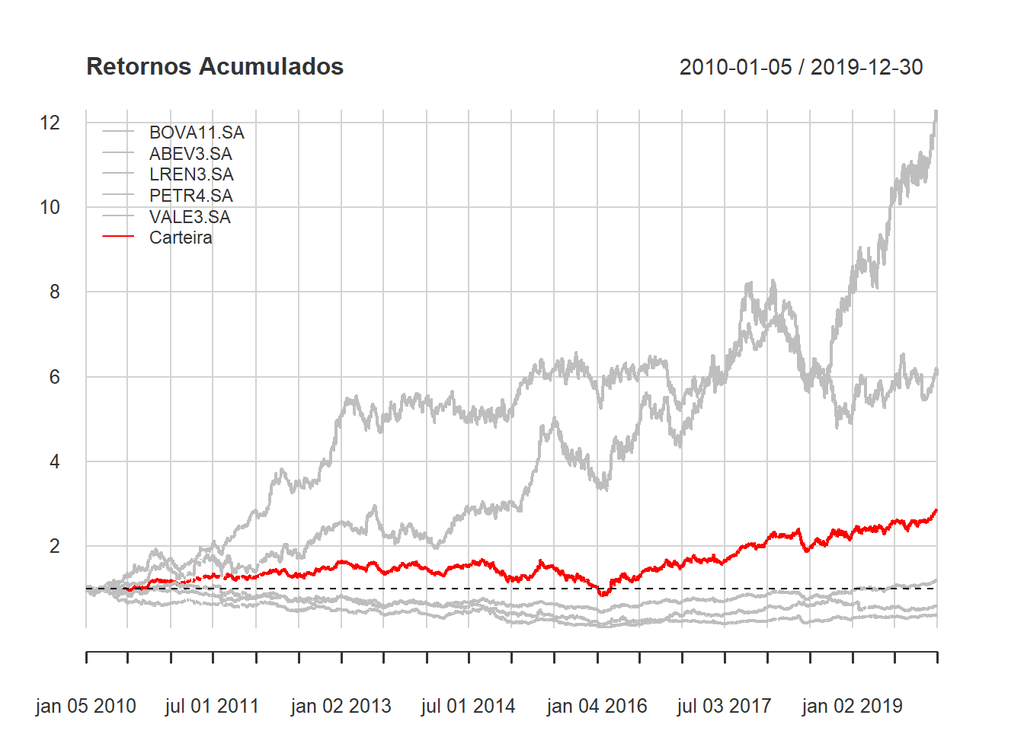

```r
{
  chart.CumReturns(returns, wealth.index = TRUE, main = "Retornos Acumulados",
                   legend.loc = 'topleft',
                   colorset = c(rep('gray', 5), 'red'))
  lines(xts(rep(1, nrow(returns)), time(returns)), col = "black", lty = 2)
}
```

Vemos que o capital investido na carteira mais que dobrou. Isso é consequência da diversificação dos investimento. Se tivessemos alocado em apenas um ou dois ativos, ficaríamos a mercê da sorte, ou da capacidade de escolha. Dividindo os ovos em diversas cestas mitigamos o rísco de um ativo ir muito pior que os outros. Eventualmente todo os ativos podem ir mau e por isso é importante conhecer outros tipos de investimento além de ações, como moedas e renda fixa, por exemplo.

Abaixo segue uma tabela gerada pela função `table.AnnualizedReturns` do PerformanceAnalytics. Nessa tabela são calculados o retorno médio no período anualizado e a medida de risco, desvio padrão anualizado.

```r
table.AnnualizedReturns(returns) %>% formattable::formattable()
```

|  | BOVA11.SA | ABEV3.SA | LREN3.SA | PETR4.SA | VALE3.SA | Carteira |
| --- | --- | --- | --- | --- | --- | --- |
| Annualized Return | 0.0176 | 0.2019 | 0.2927 | -0.0968 | -0.0528 | 0.1143 |
| Annualized Std Dev | 0.2302 | 0.2358 | 0.3370 | 0.4424 | 0.4089 | 0.2495 |
| Annualized Sharpe (Rf=0%) | 0.0765 | 0.8563 | 0.8687 | -0.2187 | -0.1291 | 0.4582 |

Note que o retorno da carteira fica em 11,43% ao ano, nada mau, essa é uma taxa de juros com dois digito e mais que dobrou o capital em 10 anos.

Uma análise interessante na formação da carteira é fazer uma análise da correlação entre os ativos. A função `chart.Correlation` do PerformanceAnalytics entrega um gráfico de correlação com todos os ativos juntos.

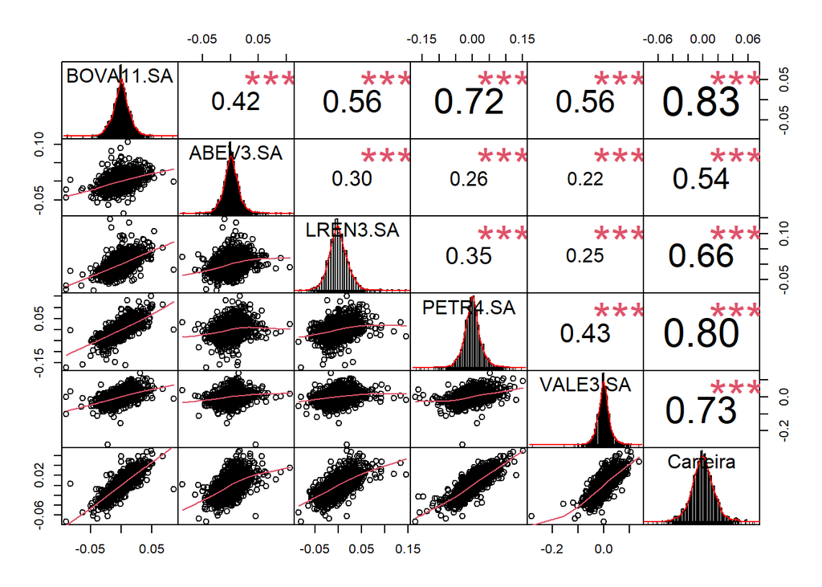

```r
chart.Correlation(returns)
```

A correlação entre Petrobrás e Vale é de 43%, enquanto a correlação entre Ambev e Lojas Renner é de 30%. Com essas correlações, uma carteira interessante poderia ser composta por Lojas Renner, Ambev e Vale, por apresentarem as menores correlações entre si. Quanto mais próxima de zero a correlação melhor é para a carteira. Isso indica que os retornos dos ativos são independentes entre si, e reduz a probabilidade de que todos caiam juntos, por exemplo.

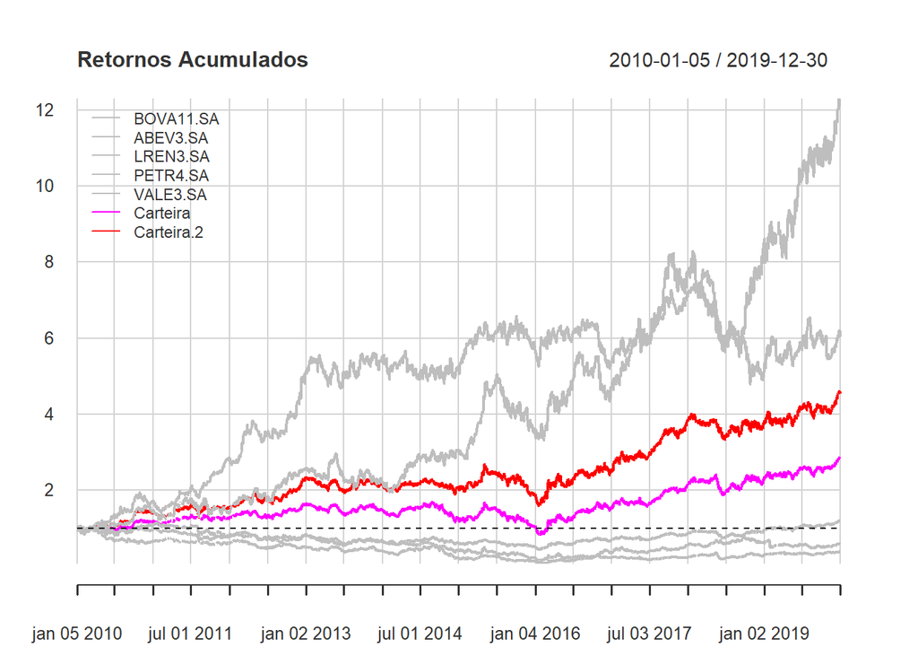

```r
weight <- 1/3
carteira <- weight * returns[,"ABEV3.SA"] + weight * returns[,"LREN3.SA"] + weight * returns[,"VALE3.SA"]
colnames(carteira) <- "Carteira 2"
returns <- merge(returns, carteira)

{
  chart.CumReturns(returns, wealth.index = TRUE, main = "Retornos Acumulados",
                   legend.loc = 'topleft',
                   colorset = c(rep('gray', 5), 'magenta', 'red'))
  lines(xts(rep(1, nrow(returns)), time(returns)), col = "black", lty = 2)
}
```

Observe que excluindo Petrobrás, por um critério objetivo, a Carteira 2 tem um desempenho duas vezes melhor que o da primeira carteira. Diversificação é o último almoço grátis no mercado financeiro. É fundamental entender as possibilidades da diversificação nos investimentos e principalmente na construção de uma carteira de investimentos. Como pudemos ver, o R oference um conjuto de ferramentas muito interessantes para essa análise.